# R Notebook

rio: Facilita la importación y exportación de datos. here: Simplifica la construcción de rutas de archivos. skimr: Proporciona resúmenes de datos rápidos y comprensibles. tidyverse: Una colección de paquetes para la ciencia de datos (como dplyr, ggplot2, tidyr, entre otros). gtsummary: Facilita la creación de tablas de resumen para la presentación de resultados. rstatix: Simplifica el análisis estadístico. janitor: Facilita la limpieza de datos. scales: Proporciona escalas y transformaciones para la visualización de datos. flextable: Permite la creación de tablas flexibles para reportes. epirhandbook: Incluye herramientas para la epidemiología aplicadas.

```r
library(viridis)
library(RColorBrewer) #paletas de colores
```

```r
linelist <- import("linelist_cleaned.rds")
```

```r
head(cleaning_dict)
```

|  | from | to | col |
| --- | --- | --- | --- |
| 1 | yes | 1 | .global |
| 2 | no | 0 | .global |
| 3 | dth | death | outcome |
| 4 | mort | death | outcome |
| 5 | femme | F | gender |
| 6 | f | F | gender |

```r
head(linelist)
```

|  | case_id | generation | date_infection | date_onset | date_hospitalisation | date_outcome | outcome | gender | age | age_unit | age_years | age_cat | age_cat5 | hospital | lon | lat | infector | source | wt_kg | ht_cm | ct_blood | fever | chills | cough | aches | vomit | temp | time_admission | bmi | … |
| --- | --- | --- | --- | --- | --- | --- | --- | --- | --- | --- | --- | --- | --- | --- | --- | --- | --- | --- | --- | --- | --- | --- | --- | --- | --- | --- | --- | --- | --- | --- |
| 1 | 5fe599 | 4 | 2014-05-08 | 2014-05-13 | 2014-05-15 |  | NA | m | 2 | years | 2 | 0-4 | 0-4 | Other | -13.21574 | 8.468973 | f547d6 | other | 27 | 48 | 22 | no | no | yes | no | yes | 36.8 | NA | 117.18750 | … |
| 2 | 8689b7 | 4 |  | 2014-05-13 | 2014-05-14 | 2014-05-18 | Recover | f | 3 | years | 3 | 0-4 | 0-4 | Missing | -13.21523 | 8.451719 | NA | NA | 25 | 59 | 22 | NA | NA | NA | NA | NA | 36.9 | 09:36 | 71.81844 | … |
| 3 | 11f8ea | 2 |  | 2014-05-16 | 2014-05-18 | 2014-05-30 | Recover | m | 56 | years | 56 | 50-69 | 55-59 | St. Mark's Maternity Hospital (SMMH) | -13.21291 | 8.464817 | NA | NA | 91 | 238 | 21 | NA | NA | NA | NA | NA | 36.9 | 16:48 | 16.06525 | … |
| 4 | b8812a | 3 | 2014-05-04 | 2014-05-18 | 2014-05-20 |  | NA | f | 18 | years | 18 | 15-19 | 15-19 | Port Hospital | -13.23637 | 8.475476 | f90f5f | other | 41 | 135 | 23 | no | no | no | no | no | 36.8 | 11:22 | 22.49657 | … |
| 5 | 893f25 | 3 | 2014-05-18 | 2014-05-21 | 2014-05-22 | 2014-05-29 | Recover | m | 3 | years | 3 | 0-4 | 0-4 | Military Hospital | -13.22286 | 8.460824 | 11f8ea | other | 36 | 71 | 23 | no | no | yes | no | yes | 36.9 | 12:60 | 71.41440 | … |
| 6 | be99c8 | 3 | 2014-05-03 | 2014-05-22 | 2014-05-23 | 2014-05-24 | Recover | f | 16 | years | 16 | 15-19 | 15-19 | Port Hospital | -13.22263 | 8.461831 | aec8ec | other | 56 | 116 | 21 | no | no | yes | no | yes | 37.6 | 14:13 | 41.61712 | … |

```r
skim(linelist)
```

Data summary

| Name | linelist |
| --- | --- |
| Number of rows | 5888 |
| Number of columns | 30 |
| _______________________ |  |
| Column type frequency: |  |
| character | 13 |
| Date | 4 |
| factor | 2 |
| numeric | 11 |
| ________________________ |  |
| Group variables | None |

**Variable type: character**

| skim_variable | n_missing | complete_rate | min | max | empty | n_unique | whitespace |
| --- | --- | --- | --- | --- | --- | --- | --- |
| case_id | 0 | 1.00 | 6 | 6 | 0 | 5888 | 0 |
| outcome | 1323 | 0.78 | 5 | 7 | 0 | 2 | 0 |
| gender | 278 | 0.95 | 1 | 1 | 0 | 2 | 0 |
| age_unit | 0 | 1.00 | 5 | 6 | 0 | 2 | 0 |
| hospital | 0 | 1.00 | 5 | 36 | 0 | 6 | 0 |
| infector | 2088 | 0.65 | 6 | 6 | 0 | 2697 | 0 |
| source | 2088 | 0.65 | 5 | 7 | 0 | 2 | 0 |
| fever | 249 | 0.96 | 2 | 3 | 0 | 2 | 0 |
| chills | 249 | 0.96 | 2 | 3 | 0 | 2 | 0 |
| cough | 249 | 0.96 | 2 | 3 | 0 | 2 | 0 |
| aches | 249 | 0.96 | 2 | 3 | 0 | 2 | 0 |
| vomit | 249 | 0.96 | 2 | 3 | 0 | 2 | 0 |
| time_admission | 765 | 0.87 | 5 | 5 | 0 | 1072 | 0 |

**Variable type: Date**

| skim_variable | n_missing | complete_rate | min | max | median | n_unique |
| --- | --- | --- | --- | --- | --- | --- |
| date_infection | 2087 | 0.65 | 2014-03-19 | 2015-04-27 | 2014-10-11 | 359 |
| date_onset | 256 | 0.96 | 2014-04-07 | 2015-04-30 | 2014-10-23 | 367 |
| date_hospitalisation | 0 | 1.00 | 2014-04-17 | 2015-04-30 | 2014-10-23 | 363 |
| date_outcome | 936 | 0.84 | 2014-04-19 | 2015-06-04 | 2014-11-01 | 371 |

**Variable type: factor**

| skim_variable | n_missing | complete_rate | ordered | n_unique | top_counts |
| --- | --- | --- | --- | --- | --- |
| age_cat | 86 | 0.99 | FALSE | 8 | 0-4: 1095, 5-9: 1095, 20-: 1073, 10-: 941 |
| age_cat5 | 86 | 0.99 | FALSE | 17 | 0-4: 1095, 5-9: 1095, 10-: 941, 15-: 743 |

**Variable type: numeric**

| skim_variable | n_missing | complete_rate | mean | sd | p0 | p25 | p50 | p75 | p100 | hist |
| --- | --- | --- | --- | --- | --- | --- | --- | --- | --- | --- |
| generation | 0 | 1.00 | 16.56 | 5.79 | 0.00 | 13.00 | 16.00 | 20.00 | 37.00 | ▁▆▇▂▁ |
| age | 86 | 0.99 | 16.07 | 12.62 | 0.00 | 6.00 | 13.00 | 23.00 | 84.00 | ▇▅▁▁▁ |
| age_years | 86 | 0.99 | 16.02 | 12.64 | 0.00 | 6.00 | 13.00 | 23.00 | 84.00 | ▇▅▁▁▁ |
| lon | 0 | 1.00 | -13.23 | 0.02 | -13.27 | -13.25 | -13.23 | -13.22 | -13.21 | ▅▃▃▆▇ |
| lat | 0 | 1.00 | 8.47 | 0.01 | 8.45 | 8.46 | 8.47 | 8.48 | 8.49 | ▅▇▇▇▆ |
| wt_kg | 0 | 1.00 | 52.64 | 18.58 | -11.00 | 41.00 | 54.00 | 66.00 | 111.00 | ▁▃▇▅▁ |
| ht_cm | 0 | 1.00 | 124.96 | 49.52 | 4.00 | 91.00 | 129.00 | 159.00 | 295.00 | ▂▅▇▂▁ |
| ct_blood | 0 | 1.00 | 21.21 | 1.69 | 16.00 | 20.00 | 22.00 | 22.00 | 26.00 | ▁▃▇▃▁ |
| temp | 149 | 0.97 | 38.56 | 0.98 | 35.20 | 38.20 | 38.80 | 39.20 | 40.80 | ▁▂▂▇▁ |
| bmi | 0 | 1.00 | 46.89 | 55.39 | -1200.00 | 24.56 | 32.12 | 50.01 | 1250.00 | ▁▁▇▁▁ |
| days_onset_hosp | 256 | 0.96 | 2.06 | 2.26 | 0.00 | 1.00 | 1.00 | 3.00 | 22.00 | ▇▁▁▁▁ |

```r
#ESTA FUNCION MUESTRA:
  #summary
    #numero columnas, numero de filas, tipos de columnas y frecuencia
  #nombre de la columna, numeros missing, ratio, minimo, maximo, vacio, numeros unicos, espacios en blanco
```

Esta tabla muestra estadísticas descriptivas para varias variables en el conjunto de datos linelist. A continuación, te explico las columnas y el significado de cada una de las estadísticas mostradas:

skim_variable: Nombre de la variable. n_missing: Número de valores faltantes (NA) en la variable. complete_rate: Proporción de valores completos (no NA) en la variable. mean: Media aritmética de la variable. sd: Desviación estándar de la variable. p0: Percentil 0 (mínimo valor) de la variable. p25: Percentil 25 de la variable (primer cuartil). p50: Percentil 50 de la variable (mediana). p75: Percentil 75 de la variable (tercer cuartil)

**Interpretación de las estadísticas**: *generation*: No tiene valores faltantes (n_missing = 0), la media es aproximadamente 16.56, y el valor oscila entre 0 y 20 (de p0 a p75). *age y age_years*: Ambas variables tienen 86 valores faltantes, una media cercana a 16 años, y valores distribuidos entre 0 y 23 años. *lon (longitud) y lat (latitud)*: No tienen valores faltantes y muestran coordenadas geográficas específicas. *wt_kg (peso en kg)*: No tiene valores faltantes, la media es aproximadamente 52.64 kg, pero tiene un valor mínimo negativo (-11), lo cual es extraño y sugiere posibles errores en los datos. *ht_cm (altura en cm)*: No tiene valores faltantes, con una media de 124.96 cm y una amplia variabilidad. *ct_blood*: No tiene valores faltantes, con una media de 21.21 y valores concentrados alrededor de 20-22. *temp (temperatura)*: Tiene 149 valores faltantes, con una media de 38.56 grados y valores típicos de la temperatura corporal. *bmi*: No tiene valores faltantes, pero muestra un valor mínimo inusualmente bajo (-1200), lo cual es claramente un error de datos.

Con la función summary() lo que hacemos es obtener también información, pero esta pertenece a R base y es algo más complicado de leer.

```r
summary(linelist)
```

```
##    case_id            generation    date_infection         date_onset
##  Length:5888        Min.   : 0.00   Min.   :2014-03-19   Min.   :2014-04-07
##  Class :character   1st Qu.:13.00   1st Qu.:2014-09-06   1st Qu.:2014-09-16
##  Mode  :character   Median :16.00   Median :2014-10-11   Median :2014-10-23
##                     Mean   :16.56   Mean   :2014-10-22   Mean   :2014-11-03
##                     3rd Qu.:20.00   3rd Qu.:2014-12-05   3rd Qu.:2014-12-19
##                     Max.   :37.00   Max.   :2015-04-27   Max.   :2015-04-30
##                                     NA's   :2087         NA's   :256
##  date_hospitalisation  date_outcome          outcome
##  Min.   :2014-04-17   Min.   :2014-04-19   Length:5888
##  1st Qu.:2014-09-19   1st Qu.:2014-09-26   Class :character
##  Median :2014-10-23   Median :2014-11-01   Mode  :character
##  Mean   :2014-11-03   Mean   :2014-11-12
##  3rd Qu.:2014-12-17   3rd Qu.:2014-12-28
##  Max.   :2015-04-30   Max.   :2015-06-04
##                       NA's   :936
##     gender               age          age_unit           age_years
##  Length:5888        Min.   : 0.00   Length:5888        Min.   : 0.00
##  Class :character   1st Qu.: 6.00   Class :character   1st Qu.: 6.00
##  Mode  :character   Median :13.00   Mode  :character   Median :13.00
##                     Mean   :16.07                      Mean   :16.02
##                     3rd Qu.:23.00                      3rd Qu.:23.00
##                     Max.   :84.00                      Max.   :84.00
##                     NA's   :86                         NA's   :86
##     age_cat        age_cat5      hospital              lon
##  0-4    :1095   0-4    :1095   Length:5888        Min.   :-13.27
##  5-9    :1095   5-9    :1095   Class :character   1st Qu.:-13.25
##  20-29  :1073   10-14  : 941   Mode  :character   Median :-13.23
##  10-14  : 941   15-19  : 743                      Mean   :-13.23
##  30-49  : 754   20-24  : 638                      3rd Qu.:-13.22
##  (Other): 844   (Other):1290                      Max.   :-13.21
##  NA's   :  86   NA's   :  86
##       lat          infector            source              wt_kg
##  Min.   :8.446   Length:5888        Length:5888        Min.   :-11.00
##  1st Qu.:8.461   Class :character   Class :character   1st Qu.: 41.00
##  Median :8.469   Mode  :character   Mode  :character   Median : 54.00
##  Mean   :8.470                                         Mean   : 52.64
##  3rd Qu.:8.480                                         3rd Qu.: 66.00
##  Max.   :8.492                                         Max.   :111.00
##
```

[output cut: 9 more lines]

```
##  Length:5888        Length:5888        Length:5888        Min.   :35.20
##  Class :character   Class :character   Class :character   1st Qu.:38.20
##  Mode  :character   Mode  :character   Mode  :character   Median :38.80
##                                                           Mean   :38.56
##                                                           3rd Qu.:39.20
##                                                           Max.   :40.80
##                                                           NA's   :149
##  time_admission          bmi           days_onset_hosp
##  Length:5888        Min.   :-1200.00   Min.   : 0.000
##  Class :character   1st Qu.:   24.56   1st Qu.: 1.000
##  Mode  :character   Median :   32.12   Median : 1.000
##                     Mean   :   46.89   Mean   : 2.059
##                     3rd Qu.:   50.01   3rd Qu.: 3.000
##                     Max.   : 1250.00   Max.   :22.000
##                                        NA's   :256
```

```r
summary(linelist$age_years)[[2]]
```

```
## [1] 6
```

```r
#1st Qu.: 6.00   ESTA ORDEN SELECIONA EL 2 ELEMENTO QUE DEVUELVE LA LISTA DE LA FUNCION SUMMARY
```

```r
#ALMACENAR LOS DATOS DE SUMMARY EN UN FORMATO DATAFRAME
#get_summary_stats( ) pertenece a la libreria rstatix
linelist %>%
get_summary_stats(
age, wt_kg, ht_cm, ct_blood, temp,
type = "common")
```

| variable | n | min | max | median | iqr | mean | sd | se | ci |
| --- | --- | --- | --- | --- | --- | --- | --- | --- | --- |
| age | 5802 | 0.0 | 84.0 | 13.0 | 17 | 16.072 | 12.620 | 0.166 | 0.325 |
| wt_kg | 5888 | -11.0 | 111.0 | 54.0 | 25 | 52.645 | 18.584 | 0.242 | 0.475 |
| ht_cm | 5888 | 4.0 | 295.0 | 129.0 | 68 | 124.963 | 49.521 | 0.645 | 1.265 |
| ct_blood | 5888 | 16.0 | 26.0 | 22.0 | 2 | 21.207 | 1.689 | 0.022 | 0.043 |
| temp | 5739 | 35.2 | 40.8 | 38.8 | 1 | 38.558 | 0.977 | 0.013 | 0.025 |

```r
linelist %>%
  tabyl(age_cat)
```

|  | age_cat | n | percent | valid_percent |
| --- | --- | --- | --- | --- |
| 1 | 0-4 | 1095 | 0.185971467 | 0.188728025 |
| 2 | 5-9 | 1095 | 0.185971467 | 0.188728025 |
| 3 | 10-14 | 941 | 0.159816576 | 0.162185453 |
| 4 | 15-19 | 743 | 0.126188859 | 0.128059290 |
| 5 | 20-29 | 1073 | 0.182235054 | 0.184936229 |
| 6 | 30-49 | 754 | 0.128057065 | 0.129955188 |
| 7 | 50-69 | 95 | 0.016134511 | 0.016373664 |
| 8 | 70+ | 6 | 0.001019022 | 0.001034126 |
| 9 | NA | 86 | 0.014605978 | NA |

```r
linelist %>%
  tabyl(age_cat, gender) %>%
  adorn_totals(where = "row") %>%
  adorn_percentages(denominator = "row") %>%
  adorn_pct_formatting(digits = 2)
```

|  | age_cat | f | m | NA_ |
| --- | --- | --- | --- | --- |
| 1 | 0-4 | 58.45% | 37.99% | 3.56% |
| 2 | 5-9 | 58.54% | 37.63% | 3.84% |
| 3 | 10-14 | 55.05% | 40.70% | 4.25% |
| 4 | 15-19 | 48.32% | 48.99% | 2.69% |
| 5 | 20-29 | 43.62% | 53.59% | 2.80% |
| 6 | 30-49 | 23.74% | 73.87% | 2.39% |
| 7 | 50-69 | 2.11% | 95.79% | 2.11% |
| 8 | 70+ | 0.00% | 83.33% | 16.67% |
| 9 | NA | 0.00% | 0.00% | 100.00% |
| 10 | Total | 47.67% | 47.61% | 4.72% |

```r
linelist %>%
  tabyl(age_cat) %>%
  adorn_pct_formatting()
```

|  | age_cat | n | percent | valid_percent |
| --- | --- | --- | --- | --- |
| 1 | 0-4 | 1095 | 18.6% | 18.9% |
| 2 | 5-9 | 1095 | 18.6% | 18.9% |
| 3 | 10-14 | 941 | 16.0% | 16.2% |
| 4 | 15-19 | 743 | 12.6% | 12.8% |
| 5 | 20-29 | 1073 | 18.2% | 18.5% |
| 6 | 30-49 | 754 | 12.8% | 13.0% |
| 7 | 50-69 | 95 | 1.6% | 1.6% |
| 8 | 70+ | 6 | 0.1% | 0.1% |
| 9 | NA | 86 | 1.5% | - |

```r
library(flextable)

linelist %>%
  tabyl(age_cat, gender) %>%
  adorn_totals(where = "row") %>%
  adorn_percentages(denominator = "row") %>%
  adorn_pct_formatting(digits = 1) %>%
  flextable()
```

| age_cat | f | m | NA_ |
| --- | --- | --- | --- |
| 0-4 | 58.4% | 38.0% | 3.6% |
| 5-9 | 58.5% | 37.6% | 3.8% |
| 10-14 | 55.0% | 40.7% | 4.3% |
| 15-19 | 48.3% | 49.0% | 2.7% |
| 20-29 | 43.6% | 53.6% | 2.8% |
| 30-49 | 23.7% | 73.9% | 2.4% |
| 50-69 | 2.1% | 95.8% | 2.1% |
| 70+ | 0.0% | 83.3% | 16.7% |
|  | 0.0% | 0.0% | 100.0% |
| Total | 47.7% | 47.6% | 4.7% |

```r
linelist %>%
  count(hospital) %>% #conteo de hospitales
  adorn_totals()      #totales
```

|  | hospital | n |
| --- | --- | --- |
| 1 | Central Hospital | 454 |
| 2 | Military Hospital | 896 |
| 3 | Missing | 1469 |
| 4 | Other | 885 |
| 5 | Port Hospital | 1762 |
| 6 | St. Mark's Maternity Hospital (SMMH) | 422 |
| 7 | Total | 5888 |

```r
table(cleaning_dict)
```

```
## , , col = .global
##
##                to
## from            0 1 death F funeral M Port Hospital
##   dth           0 0     0 0       0 0             0
##   f             0 0     0 0       0 0             0
##   femme         0 0     0 0       0 0             0
##   funeraille    0 0     0 0       0 0             0
##   m             0 0     0 0       0 0             0
##   mort          0 0     0 0       0 0             0
##   no            1 0     0 0       0 0             0
##   Port hospital 0 0     0 0       0 0             0
##   yes           0 1     0 0       0 0             0
##
## , , col = gender
##
##                to
## from            0 1 death F funeral M Port Hospital
##   dth           0 0     0 0       0 0             0
##   f             0 0     0 1       0 0             0
##   femme         0 0     0 1       0 0             0
##   funeraille    0 0     0 0       0 0             0
##   m             0 0     0 0       0 1             0
##   mort          0 0     0 0       0 0             0
##   no            0 0     0 0       0 0             0
##   Port hospital 0 0     0 0       0 0             0
##   yes           0 0     0 0       0 0             0
##
## , , col = hospital
##
##                to
## from            0 1 death F funeral M Port Hospital
##   dth           0 0     0 0       0 0             0
##   f             0 0     0 0       0 0             0
##   femme         0 0     0 0       0 0             0
##   funeraille    0 0     0 0       0 0             0
##   m             0 0     0 0       0 0             0
##   mort          0 0     0 0       0 0             0
##   no            0 0     0 0       0 0             0
##   Port hospital 0 0     0 0       0 0             1
```

[output cut: 14 more lines]

```
##   yes           0 0     0 0       0 0             0
##
## , , col = source
##
##                to
## from            0 1 death F funeral M Port Hospital
##   dth           0 0     0 0       0 0             0
##   f             0 0     0 0       0 0             0
##   femme         0 0     0 0       0 0             0
##   funeraille    0 0     0 0       1 0             0
##   m             0 0     0 0       0 0             0
##   mort          0 0     0 0       0 0             0
##   no            0 0     0 0       0 0             0
##   Port hospital 0 0     0 0       0 0             0
##   yes           0 0     0 0       0 0             0
```

```r
linelist %>%
  summarise(n_row = n())
```

| n_row |
| --- |
| 5888 |

la funcion group_by() ayuda a agrupar

```r
linelist %>%
  group_by(age_cat) %>%
  summarise(n_rows= n())
```

| age_cat | n_rows |
| --- | --- |
| 0-4 | 1095 |
| 5-9 | 1095 |
| 10-14 | 941 |
| 15-19 | 743 |
| 20-29 | 1073 |
| 30-49 | 754 |
| 50-69 | 95 |
| 70+ | 6 |
| NA | 86 |

```r
linelist %>%
  count(age_cat)
```

| age_cat | n |
| --- | --- |
| 0-4 | 1095 |
| 5-9 | 1095 |
| 10-14 | 941 |
| 15-19 | 743 |
| 20-29 | 1073 |
| 30-49 | 754 |
| 50-69 | 95 |
| 70+ | 6 |
| NA | 86 |

```r
linelist %>%
  count('Categorias de edades' = age_cat, 'Brote' =  outcome, name = "Recuento") #funcion y opciones
```

| Categorias de edades | Brote | Recuento |
| --- | --- | --- |
| 0-4 | Death | 471 |
| 0-4 | Recover | 364 |
| 0-4 | NA | 260 |
| 5-9 | Death | 476 |
| 5-9 | Recover | 391 |
| 5-9 | NA | 228 |
| 10-14 | Death | 438 |
| 10-14 | Recover | 303 |
| 10-14 | NA | 200 |
| 15-19 | Death | 323 |

[output cut: 16 more lines]

```r
age_summary <-  linelist %>%
                count("Categorias de edades" = age_cat, name = "recuento") %>%
                mutate(percent =scales::percent(recuento / sum(recuento)))
age_summary
```

| Categorias de edades | recuento | percent |
| --- | --- | --- |
| 0-4 | 1095 | 18.60% |
| 5-9 | 1095 | 18.60% |
| 10-14 | 941 | 15.98% |
| 15-19 | 743 | 12.62% |
| 20-29 | 1073 | 18.22% |
| 30-49 | 754 | 12.81% |
| 50-69 | 95 | 1.61% |
| 70+ | 6 | 0.10% |
| NA | 86 | 1.46% |

```r
age_summary %>%
  flextable()
```

| Categorias de edades | recuento | percent |
| --- | --- | --- |
| 0-4 | 1,095 | 18.60% |
| 5-9 | 1,095 | 18.60% |
| 10-14 | 941 | 15.98% |
| 15-19 | 743 | 12.62% |
| 20-29 | 1,073 | 18.22% |
| 30-49 | 754 | 12.81% |
| 50-69 | 95 | 1.61% |
| 70+ | 6 | 0.10% |
|  | 86 | 1.46% |

```r
library(ggplot2)
```

```r
age_summary <- linelist %>%
  count(age_cat, outcome) %>%
  mutate(percent = scales::percent(n / sum(n)))
```

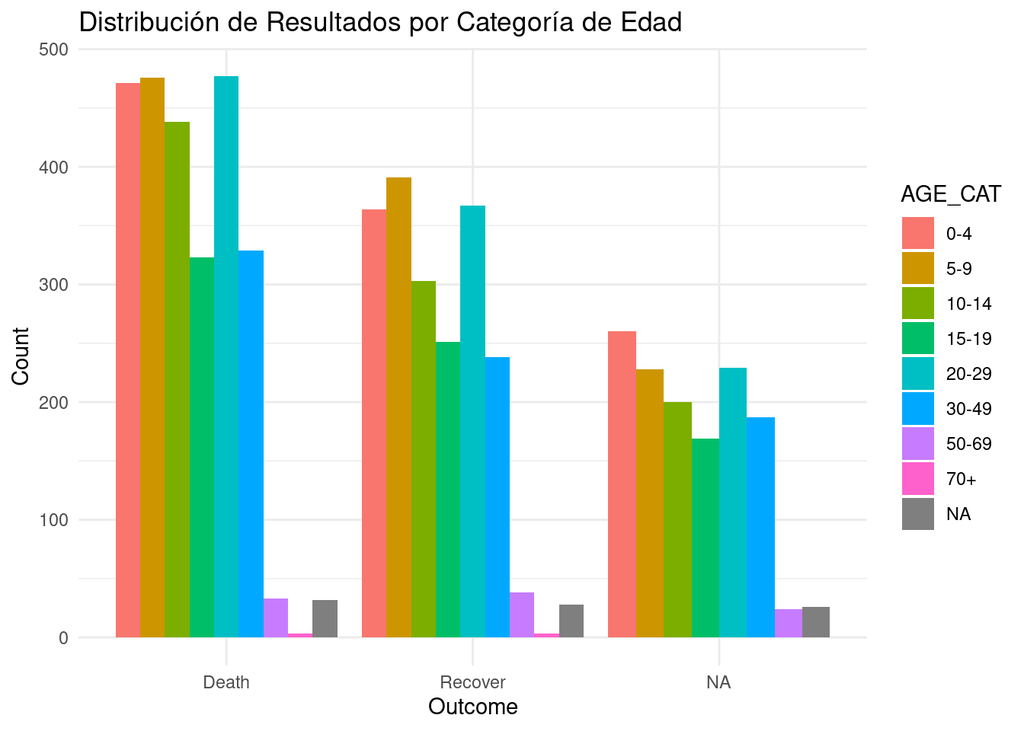

```r
ggplot(age_summary, aes(x = outcome, y = n, fill = age_cat)) +
  geom_bar(stat = "identity", position = "dodge") +
  labs(title = "Distribución de Resultados por Categoría de Edad",
       x = "Outcome",
       y = "Count",
       fill = "AGE_CAT") +
  theme_minimal()
```

```
## No summary function supplied, defaulting to `mean_se()`
```

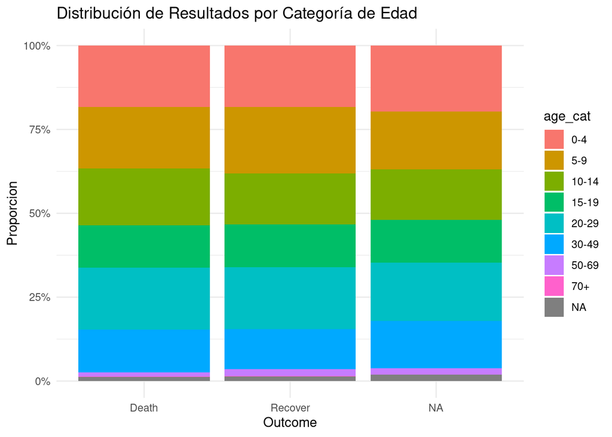

```r
ggplot(age_summary, aes(x = outcome, y = n, fill = age_cat)) +
  geom_bar(stat = "summary", position = "fill") +
  scale_y_continuous(labels = scales::percent_format()) +
  labs(title = "Distribución de Resultados por Categoría de Edad",
       x = "Outcome",
       y = "Proporcion",
       fill = "age_cat") +
  theme_minimal()
```

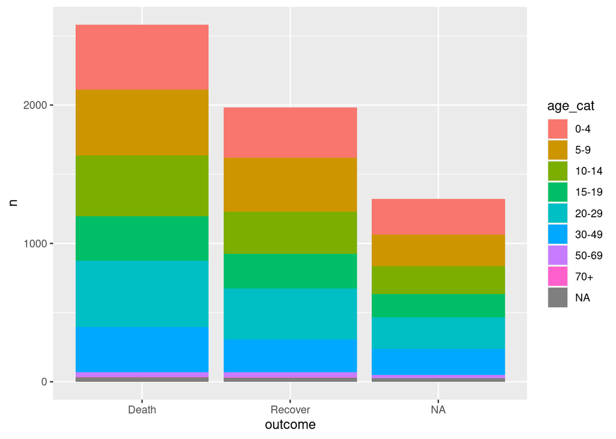

```r
linelist %>%
  count(age_cat, outcome) %>%
  ggplot()+
  geom_col(
    mapping = aes(
      x=outcome,
      fill = age_cat,
      y=n
    )
  )
```

```r
unique(linelist$outcome)
```

```
## [1] NA        "Recover" "Death"
```

[figure not shown]

```r
ggplot(linelist, aes(x = outcome, fill = gender)) +
geom_bar(position = "fill") +
  scale_y_continuous(labels = scales::percent_format()) +
  labs(title = "Distribución de OUTCOME según GENERO",
       x = "Género",
       y = "Proporción",
       fill = "Outcome") +
  theme_minimal()
```

```r
pie_data <- linelist %>%
  group_by(outcome, gender) %>%
  summarise(n = n()) %>%
  ungroup()
```

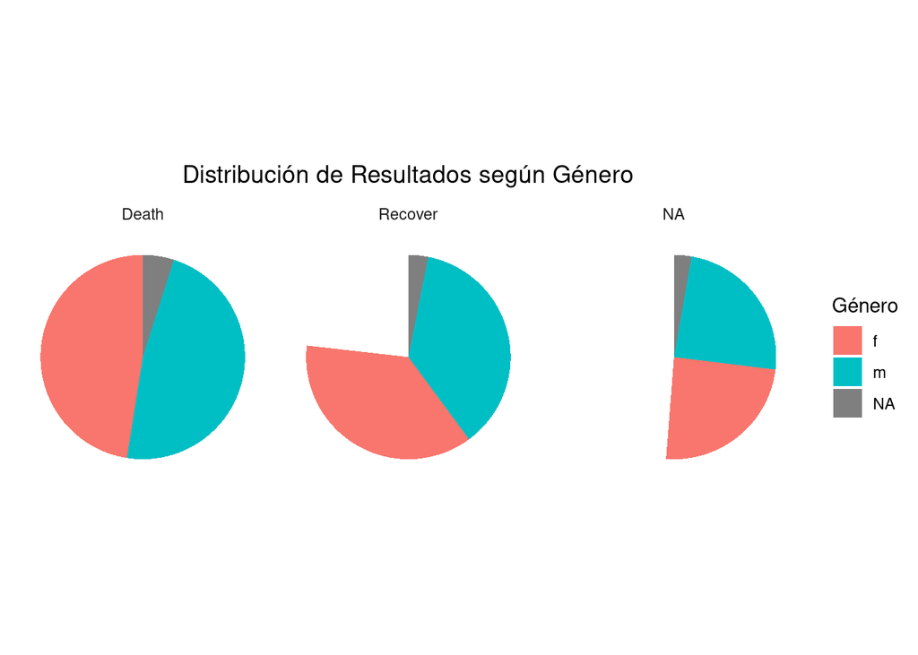

```r
ggplot(pie_data, aes(x = "", y = n, fill = gender)) +
  geom_bar(width = 1, stat = "identity") +
  coord_polar(theta = "y") +
  facet_wrap(~outcome) +
  labs(title = "Distribución de Resultados según Género",
       x = NULL,
       y = NULL,
       fill = "Género") +
  theme_minimal() +
  theme(axis.ticks = element_blank(),
        axis.text = element_blank(),
        panel.grid = element_blank(),
        plot.title = element_text(hjust = 0.5))
```

```r
summary_table <- linelist %>%
  group_by(hospital) %>%
  summarise(
    casos = n(),
    delay_max = max(days_onset_hosp, na.rm = TRUE),
    delay_mean = round(mean(days_onset_hosp, na.rm = TRUE), digits = 2),
    delay_sd = round(sd(days_onset_hosp, na.rm = TRUE), digits = 2),
    delay_3 = sum(days_onset_hosp <= 3, na.rm = TRUE),
    pct_delay_3 = percent(delay_3 / casos)
  )
summary_table
```

| hospital | casos | delay_max | delay_mean | delay_sd | delay_3 | pct_delay_3 |
| --- | --- | --- | --- | --- | --- | --- |
| Central Hospital | 454 | 12 | 1.89 | 1.95 | 378 | 83% |
| Military Hospital | 896 | 15 | 2.12 | 2.36 | 713 | 80% |
| Missing | 1469 | 22 | 2.08 | 2.29 | 1156 | 79% |
| Other | 885 | 18 | 2.05 | 2.23 | 696 | 79% |
| Port Hospital | 1762 | 16 | 2.05 | 2.24 | 1401 | 80% |
| St. Mark's Maternity Hospital (SMMH) | 422 | 18 | 2.08 | 2.33 | 339 | 80% |

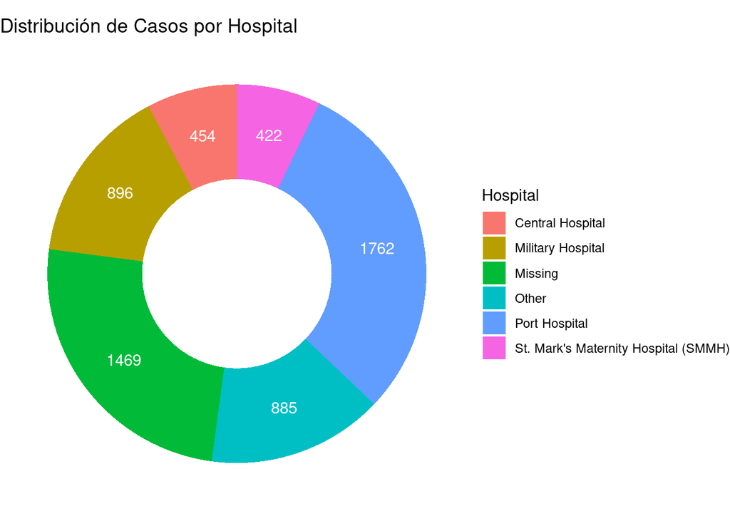

```r
ggplot(summary_table, aes(x = 2, y = casos, fill = hospital)) +
  geom_bar(stat = "identity", width = 1) +
  coord_polar(theta = "y") +
  xlim(0.5, 2.5) +
  labs(title = "Distribución de Casos por Hospital",
       fill = "Hospital") +
  theme_void() +
  geom_text(aes(label = casos), position = position_stack(vjust = 0.5), color = "white")
```

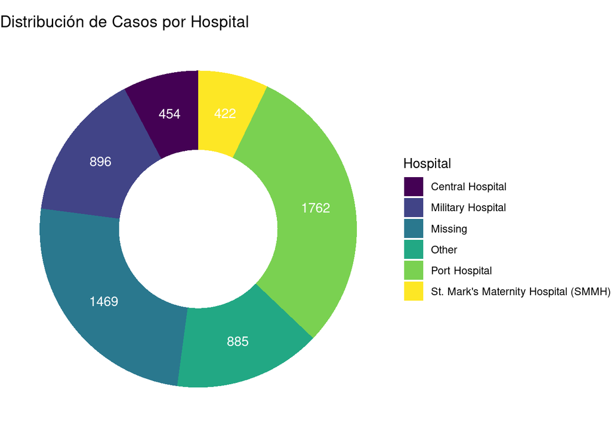

```r
ggplot(summary_table, aes(x = 2, y = casos, fill = hospital)) +
  geom_bar(stat = "identity", width = 1) +
  coord_polar(theta = "y") +
  xlim(0.5, 2.5) +
  labs(title = "Distribución de Casos por Hospital",
       fill = "Hospital") +
  theme_void() +
  geom_text(aes(label = casos), position = position_stack(vjust = 0.5), color = "white") +
  scale_fill_viridis(discrete = TRUE)
```

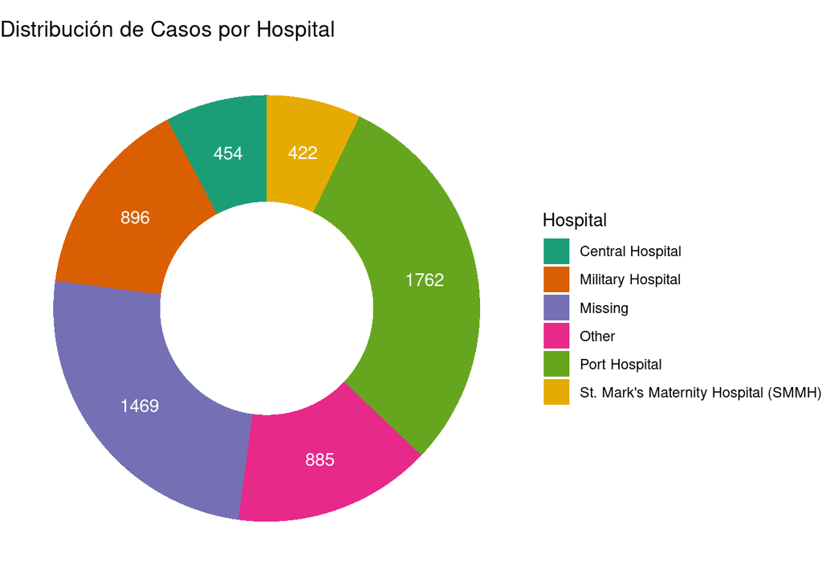

```r
ggplot(summary_table, aes(x = 2, y = casos, fill = hospital)) +
  geom_bar(stat = "identity", width = 1) +
  coord_polar(theta = "y") +
  xlim(0.5, 2.5) +
  labs(title = "Distribución de Casos por Hospital",
       fill = "Hospital") +
  theme_void() +
  geom_text(aes(label = casos), position = position_stack(vjust = 0.5), color = "white") +
  scale_fill_manual(values = brewer.pal(n = 8, name = "Dark2"))
```

```r
linelist %>%
  group_by(hospital) %>%
  summarise(
    max_temp_fvr = max(temp[fever =="yes"], na.rm =T),
    max_temp_NO = max(temp[fever =="no"], na.rm =T)
  )
```

| hospital | max_temp_fvr | max_temp_NO |
| --- | --- | --- |
| Central Hospital | 40.4 | 38.0 |
| Military Hospital | 40.5 | 38.0 |
| Missing | 40.6 | 38.0 |
| Other | 40.8 | 37.9 |
| Port Hospital | 40.6 | 38.0 |
| St. Mark's Maternity Hospital (SMMH) | 40.6 | 37.9 |

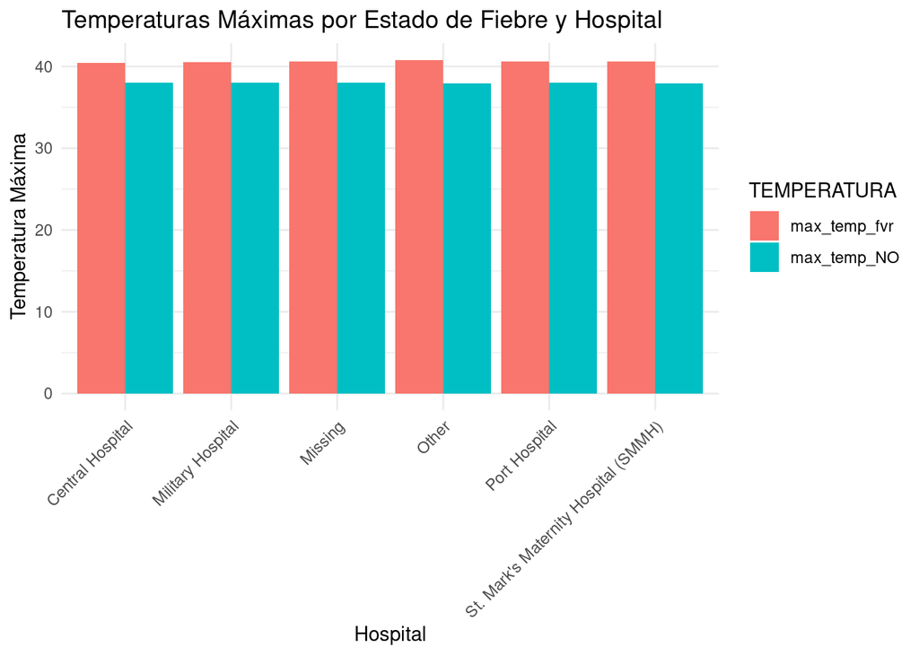

```r
temperature_summary <- linelist %>%
  group_by(hospital) %>%
  summarise(
    max_temp_fvr = max(temp[fever == "yes"], na.rm = TRUE),
    max_temp_NO = max(temp[fever == "no"], na.rm = TRUE)
  )

# Convertir los datos a formato largo (tidy) para facilitar la visualización
temperature_summary_long <- temperature_summary %>%
  pivot_longer(cols = c(max_temp_fvr, max_temp_NO),
               names_to = "fever_status",
               values_to = "max_temperature")

# Gráfico de barras
ggplot(temperature_summary_long, aes(x = hospital, y = max_temperature, fill = fever_status)) +
  geom_bar(stat = "identity", position = "dodge") +
  labs(title = "Temperaturas Máximas por Estado de Fiebre y Hospital",
       x = "Hospital",
       y = "Temperatura Máxima",
       fill = "TEMPERATURA") +
  theme_minimal() +
  theme(axis.text.x = element_text(angle = 45, hjust = 1))
```

```r
#glue lo que hace es unir datos.
summary_table %>%
  mutate(delay =str_glue("{delay_mean} ({delay_sd})")) %>%
  select(-c (delay_mean, delay_sd)) %>%
  adorn_totals(where ="row") %>%
  select(
    "Hospital" =hospital,
    "Casos"=casos,
    "Demora Maxima" =delay_max,
    "Media(sd)" = delay,
    "Demora + 3 dias" = delay_3,
    "% Demora + 3 dias" =pct_delay_3
  )
```

| Hospital | Casos | Demora Maxima | Media(sd) | Demora + 3 dias | % Demora + 3 dias |
| --- | --- | --- | --- | --- | --- |
| Central Hospital | 454 | 12 | 1.89 (1.95) | 378 | 83% |
| Military Hospital | 896 | 15 | 2.12 (2.36) | 713 | 80% |
| Missing | 1469 | 22 | 2.08 (2.29) | 1156 | 79% |
| Other | 885 | 18 | 2.05 (2.23) | 696 | 79% |
| Port Hospital | 1762 | 16 | 2.05 (2.24) | 1401 | 80% |
| St. Mark's Maternity Hospital (SMMH) | 422 | 18 | 2.08 (2.33) | 339 | 80% |
| Total | 5888 | 101 | - | 4683 | - |

```r
names(linelist)
```

```
##  [1] "case_id"              "generation"           "date_infection"
##  [4] "date_onset"           "date_hospitalisation" "date_outcome"
##  [7] "outcome"              "gender"               "age"
## [10] "age_unit"             "age_years"            "age_cat"
## [13] "age_cat5"             "hospital"             "lon"
## [16] "lat"                  "infector"             "source"
## [19] "wt_kg"                "ht_cm"                "ct_blood"
## [22] "fever"                "chills"               "cough"
## [25] "aches"                "vomit"                "temp"
## [28] "time_admission"       "bmi"                  "days_onset_hosp"
```

```r
unique(linelist$chills)
```

```
## [1] "no"  NA    "yes"
```

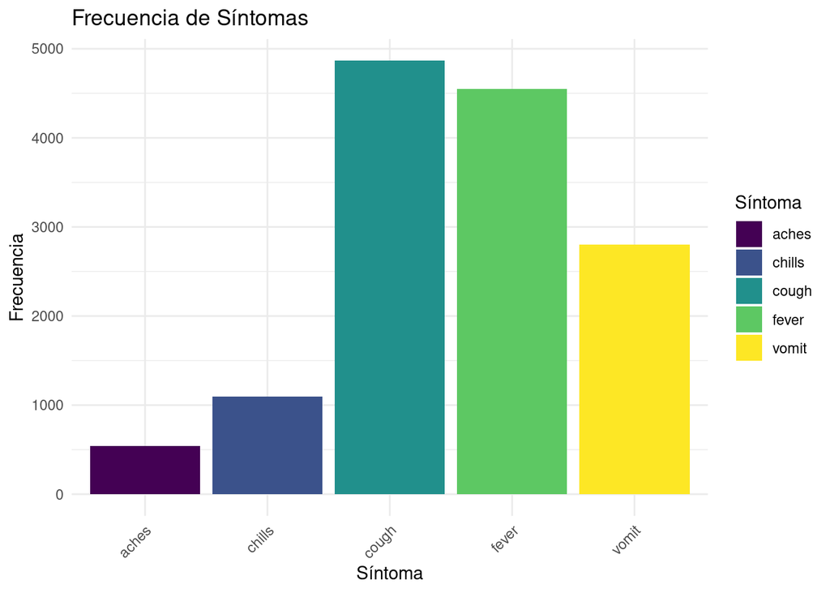

```r
# Filtrar el dataframe para incluir solo filas donde el síntoma es "sí"
symptoms_freq <- linelist %>%
  summarise(across(c(fever, chills, cough, aches, vomit), ~sum(. == "yes", na.rm = TRUE)))


# Convertir a formato largo (tidy)
symptoms_freq_long <- symptoms_freq %>%
  pivot_longer(cols = everything(),
               names_to = "symptom",
               values_to = "frequency")

# Crear el gráfico de barras
ggplot(symptoms_freq_long, aes(x = symptom, y = frequency, fill = symptom)) +
  geom_bar(stat = "identity") +
  labs(title = "Frecuencia de Síntomas",
       x = "Síntoma",
       y = "Frecuencia",
       fill = "Síntoma") +
  theme_minimal() +
  theme(axis.text.x = element_text(angle = 45, hjust = 1)) +
  scale_fill_viridis(discrete = TRUE)
```

```r
#PERCENTILES

linelist %>%
  summarise(age_percentiles = quantile(age_years, na.rm =TRUE))
```

| age_percentiles |
| --- |
| 0 |
| 6 |
| 13 |
| 23 |
| 84 |

```r
linelist %>%
  summarise(
    age_percentiles = quantile(age_years, probs = c(.05, 0.5, 0.75, 0.980) , na.rm =TRUE))
```

| age_percentiles |
| --- |
| 1 |
| 13 |
| 23 |
| 48 |

```r
linelist %>%
  group_by(hospital) %>%
  summarise(
    p05 = quantile(age_years, probs = 0.05, na.rm = TRUE),
    p50 = quantile(age_years, probs = 0.50, na.rm = TRUE),
    p75 = quantile(age_years, probs = 0.75, na.rm = TRUE),
    p98 = quantile(age_years, probs = 0.98, na.rm = TRUE)
  )
```

| hospital | p05 | p50 | p75 | p98 |
| --- | --- | --- | --- | --- |
| Central Hospital | 1 | 12 | 21 | 48.00 |
| Military Hospital | 1 | 13 | 24 | 45.00 |
| Missing | 1 | 13 | 23 | 48.20 |
| Other | 1 | 13 | 23 | 50.00 |
| Port Hospital | 1 | 14 | 24 | 49.00 |
| St. Mark's Maternity Hospital (SMMH) | 2 | 12 | 22 | 50.24 |

```r
linelist %>%
  rstatix::get_summary_stats(age, type = "quantile")
```

| variable | n | 0% | 25% | 50% | 75% | 100% |
| --- | --- | --- | --- | --- | --- | --- |
| age | 5802 | 0 | 6 | 13 | 23 | 84 |

```r
linelist_agg <-  linelist %>%
  drop_na(gender, outcome) %>%
  count(outcome, gender)

linelist_agg
```

| outcome | gender | n |
| --- | --- | --- |
| Death | f | 1227 |
| Death | m | 1228 |
| Recover | f | 953 |
| Recover | m | 950 |

```r
linelist_agg %>%
  group_by (outcome) %>%
  summarise(
    total_cases = sum(n, na.rm=T),
    male_cases = sum(n[gender == "m"], na.rm=T),
    female_cases = sum(n[gender == "f"], na.rm=T)

  )
```

| outcome | total_cases | male_cases | female_cases |
| --- | --- | --- | --- |
| Death | 2455 | 1228 | 1227 |
| Recover | 1903 | 950 | 953 |

```r
linelist %>%
  group_by(outcome) %>%
  summarise(round(across(.cols = c(age_years, temp, wt_kg, ht_cm),
                    .fns = mean,
                    na.rm=T), digits = 2))
```

| outcome | age_years | temp | wt_kg | ht_cm |
| --- | --- | --- | --- | --- |
| Death | 15.88 | 38.56 | 52.59 | 124.86 |
| Recover | 16.06 | 38.56 | 52.48 | 124.98 |
| NA | 16.24 | 38.55 | 53.01 | 125.13 |

```r
linelist %>%
  group_by(outcome) %>%
  summarise(round(across(.cols = c(age_years, temp, wt_kg, ht_cm),
                   .fns = list("mean" = mean, "sd" = sd),
                   na.rm=T                   ), digits = 3))
```

| outcome | age_years_mean | age_years_sd | temp_mean | temp_sd | wt_kg_mean | wt_kg_sd | ht_cm_mean | ht_cm_sd |
| --- | --- | --- | --- | --- | --- | --- | --- | --- |
| Death | 15.879 | 12.310 | 38.560 | 0.962 | 52.585 | 18.399 | 124.864 | 48.670 |
| Recover | 16.056 | 12.959 | 38.562 | 0.997 | 52.480 | 18.637 | 124.985 | 50.065 |
| NA | 16.236 | 12.809 | 38.551 | 0.976 | 53.008 | 18.871 | 125.125 | 50.378 |

```r
linelist %>%
  group_by(outcome) %>%
  summarise(round(across(
    .cols = where(is.numeric),
    .fns = mean,
    na.rm =T ), digits = 2))
```

| outcome | generation | age | age_years | lon | lat | wt_kg | ht_cm | ct_blood | temp | bmi | days_onset_hosp |
| --- | --- | --- | --- | --- | --- | --- | --- | --- | --- | --- | --- |
| Death | 16.75 | 15.90 | 15.88 | -13.23 | 8.47 | 52.59 | 124.86 | 21.26 | 38.56 | 45.56 | 1.84 |
| Recover | 16.36 | 16.16 | 16.06 | -13.23 | 8.47 | 52.48 | 124.98 | 21.14 | 38.56 | 47.66 | 2.34 |
| NA | 16.51 | 16.27 | 16.24 | -13.23 | 8.47 | 53.01 | 125.13 | 21.21 | 38.55 | 48.35 | 2.07 |

```r
age_by_outcome <- linelist %>%
  group_by(outcome) %>%
  count(age_cat) %>%
  mutate(percent = scales::percent(n/sum(n)))
age_by_outcome
```

| outcome | age_cat | n | percent |
| --- | --- | --- | --- |
| Death | 0-4 | 471 | 18.242% |
| Death | 5-9 | 476 | 18.435% |
| Death | 10-14 | 438 | 16.964% |
| Death | 15-19 | 323 | 12.510% |
| Death | 20-29 | 477 | 18.474% |
| Death | 30-49 | 329 | 12.742% |
| Death | 50-69 | 33 | 1.278% |
| Death | 70+ | 3 | 0.116% |
| Death | NA | 32 | 1.239% |
| Recover | 0-4 | 364 | 18.36% |

[output cut: 16 more lines]

```r
age_by_outcome %>%
  select(-percent) %>%
  pivot_wider(names_from = age_cat, values_from = n)
```

| outcome | 0-4 | 5-9 | 10-14 | 15-19 | 20-29 | 30-49 | 50-69 | 70+ | NA |
| --- | --- | --- | --- | --- | --- | --- | --- | --- | --- |
| Death | 471 | 476 | 438 | 323 | 477 | 329 | 33 | 3 | 32 |
| Recover | 364 | 391 | 303 | 251 | 367 | 238 | 38 | 3 | 28 |
| NA | 260 | 228 | 200 | 169 | 229 | 187 | 24 | NA | 26 |

```r
linelist %>%
  group_by(gender) %>%
  summarise(
    know_outcome = sum(!is.na(outcome)),
    n_death = sum(outcome == "Death", na.rm =T),
    n_recover = sum(outcome == "Recover", na.rm=T),
      ) %>%
adorn_totals() %>%
  adorn_percentages("col") %>%
  adorn_pct_formatting() %>%
  adorn_ns(position= "front")
```

| gender | know_outcome | n_death | n_recover |
| --- | --- | --- | --- |
| f | 2,180 (47.8%) | 1,227 (47.5%) | 953 (48.1%) |
| m | 2,178 (47.7%) | 1,228 (47.6%) | 950 (47.9%) |
| NA | 207 (4.5%) | 127 (4.9%) | 80 (4.0%) |
| Total | 4,565 (100.0%) | 2,582 (100.0%) | 1,983 (100.0%) |

```r
by_hospital <- linelist %>%
  filter(!is.na(outcome) & hospital != "Missing") %>%
  group_by(hospital, outcome) %>%
  summarise(
    N= n(),
    ct_value = median(ct_blood, na.rm=T)
  )
by_hospital
```

| hospital | outcome | N | ct_value |
| --- | --- | --- | --- |
| Central Hospital | Death | 193 | 22 |
| Central Hospital | Recover | 165 | 22 |
| Military Hospital | Death | 399 | 21 |
| Military Hospital | Recover | 309 | 22 |
| Other | Death | 395 | 22 |
| Other | Recover | 290 | 21 |
| Port Hospital | Death | 785 | 22 |
| Port Hospital | Recover | 579 | 21 |
| St. Mark's Maternity Hospital (SMMH) | Death | 199 | 22 |
| St. Mark's Maternity Hospital (SMMH) | Recover | 126 | 22 |

```r
totals <-  linelist %>%
  filter(!is.na(outcome) & hospital != "Missing") %>%
  group_by(outcome) %>%
  summarise(
    N= n(),
    ct_value = median(ct_blood, na.rm=T))
totals
```

| outcome | N | ct_value |
| --- | --- | --- |
| Death | 1971 | 22 |
| Recover | 1469 | 22 |

```r
table_long <-  bind_rows(by_hospital, totals) %>%
  mutate(hospital = replace_na(hospital, "Total"))

table_long
```

| hospital | outcome | N | ct_value |
| --- | --- | --- | --- |
| Central Hospital | Death | 193 | 22 |
| Central Hospital | Recover | 165 | 22 |
| Military Hospital | Death | 399 | 21 |
| Military Hospital | Recover | 309 | 22 |
| Other | Death | 395 | 22 |
| Other | Recover | 290 | 21 |
| Port Hospital | Death | 785 | 22 |
| Port Hospital | Recover | 579 | 21 |
| St. Mark's Maternity Hospital (SMMH) | Death | 199 | 22 |
| St. Mark's Maternity Hospital (SMMH) | Recover | 126 | 22 |

[output cut: 2 more lines]

```r
table_long %>%
  mutate(hospital = replace_na(hospital, "Total")) %>%
  pivot_wider(
    values_from = c(ct_value, N),
    names_from = outcome
  ) %>%
  mutate(
    N_Known = N_Death + N_Recover,
    Pct_Death = percent(N_Death / N_Known, 0.1),
    Pct_Recover = percent(N_Recover / N_Known, 0.1)
  ) %>%
  select(
    hospital, N_Known,
    N_Recover, Pct_Recover, ct_value_Recover,
    N_Death, Pct_Death, ct_value_Death
  ) %>%
  arrange(N_Known)
```

| hospital | N_Known | N_Recover | Pct_Recover | ct_value_Recover | N_Death | Pct_Death | ct_value_Death |
| --- | --- | --- | --- | --- | --- | --- | --- |
| St. Mark's Maternity Hospital (SMMH) | 325 | 126 | 38.8% | 22 | 199 | 61.2% | 22 |
| Central Hospital | 358 | 165 | 46.1% | 22 | 193 | 53.9% | 22 |
| Other | 685 | 290 | 42.3% | 21 | 395 | 57.7% | 22 |
| Military Hospital | 708 | 309 | 43.6% | 22 | 399 | 56.4% | 21 |
| Port Hospital | 1364 | 579 | 42.4% | 21 | 785 | 57.6% | 22 |
| Total | 3440 | 1469 | 42.7% | 22 | 1971 | 57.3% | 22 |

```r
table(linelist$outcome, useNA = "always")
```

```
##
##   Death Recover    <NA>
##    2582    1983    1323
```

```r
age_by_outcome <- table(linelist$age_cat, linelist$outcome, useNA = "always")
age_by_outcome
```

```
##
##         Death Recover <NA>
##   0-4     471     364  260
##   5-9     476     391  228
##   10-14   438     303  200
##   15-19   323     251  169
##   20-29   477     367  229
##   30-49   329     238  187
##   50-69    33      38   24
##   70+       3       3    0
##   <NA>     32      28   26
```

```r
prop.table(age_by_outcome, 1) %>% round(2)
```

```
##
##         Death Recover <NA>
##   0-4    0.43    0.33 0.24
##   5-9    0.43    0.36 0.21
##   10-14  0.47    0.32 0.21
##   15-19  0.43    0.34 0.23
##   20-29  0.44    0.34 0.21
##   30-49  0.44    0.32 0.25
##   50-69  0.35    0.40 0.25
##   70+    0.50    0.50 0.00
##   <NA>   0.37    0.33 0.30
```

```r
addmargins(age_by_outcome)
```

```
##
##         Death Recover <NA>  Sum
##   0-4     471     364  260 1095
##   5-9     476     391  228 1095
##   10-14   438     303  200  941
##   15-19   323     251  169  743
##   20-29   477     367  229 1073
##   30-49   329     238  187  754
##   50-69    33      38   24   95
##   70+       3       3    0    6
##   <NA>     32      28   26   86
##   Sum    2582    1983 1323 5888
```

```r
table( fct_explicit_na(linelist$age_cat), fct_explicit_na(linelist$outcome)) %>%
  addmargins() %>%
  as.data.frame.matrix() %>%
  tibble::rownames_to_column(var = "Age Category") %>%
  flextable::flextable()
```

| Age Category | Death | Recover | (Missing) | Sum |
| --- | --- | --- | --- | --- |
| 0-4 | 471 | 364 | 260 | 1,095 |
| 5-9 | 476 | 391 | 228 | 1,095 |
| 10-14 | 438 | 303 | 200 | 941 |
| 15-19 | 323 | 251 | 169 | 743 |
| 20-29 | 477 | 367 | 229 | 1,073 |
| 30-49 | 329 | 238 | 187 | 754 |
| 50-69 | 33 | 38 | 24 | 95 |
| 70+ | 3 | 3 | 0 | 6 |
| (Missing) | 32 | 28 | 26 | 86 |
| Sum | 2,582 | 1,983 | 1,323 | 5,888 |

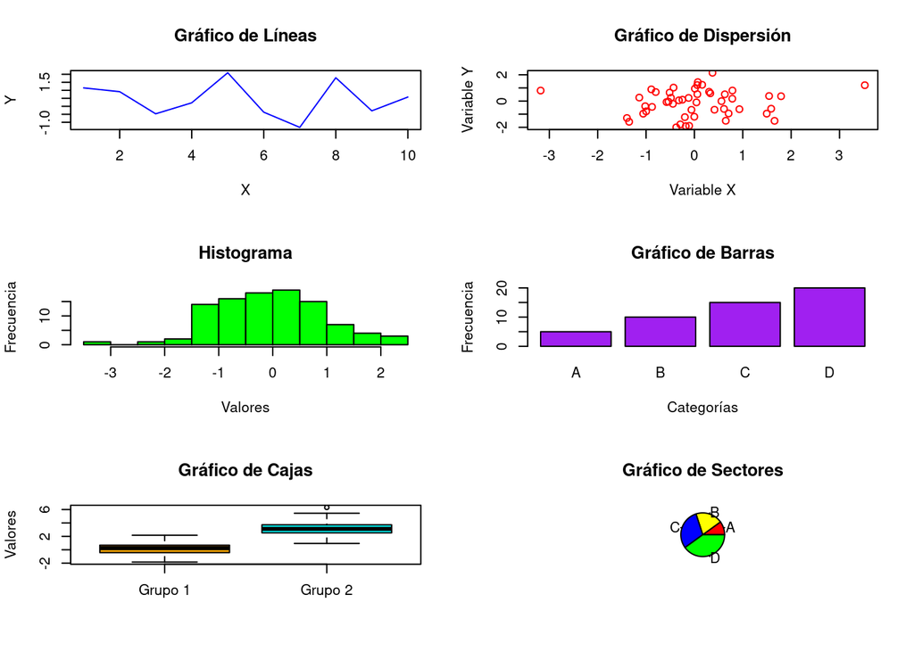

```r
# Configurar el diseño de la disposición de gráficos
par(mfrow = c(3, 2))

# Gráfico 1: Gráfico de líneas simple
x <- 1:10
y <- rnorm(10)
plot(x, y, type = "l", col = "blue", main = "Gráfico de Líneas", xlab = "X", ylab = "Y")

# Gráfico 2: Gráfico de dispersión simple
x <- rnorm(50)
y <- rnorm(50)
plot(x, y, col = "red", main = "Gráfico de Dispersión", xlab = "Variable X", ylab = "Variable Y")

# Gráfico 3: Histograma simple
data <- rnorm(100)
hist(data, col = "green", main = "Histograma", xlab = "Valores", ylab = "Frecuencia")

# Gráfico 4: Gráfico de barras simple
categories <- c("A", "B", "C", "D")
counts <- c(5, 10, 15, 20)
barplot(counts, names.arg = categories, col = "purple", main = "Gráfico de Barras", xlab = "Categorías", ylab = "Frecuencia")

# Gráfico 5: Gráfico de cajas (boxplot) simple
data1 <- rnorm(50)
data2 <- rnorm(50, mean = 3)
boxplot(data1, data2, names = c("Grupo 1", "Grupo 2"), col = c("orange", "cyan"), main = "Gráfico de Cajas", ylab = "Valores")

# Gráfico 6: Gráfico de sectores (pie chart) simple
slices <- c(10, 20, 30, 40)
labels <- c("A", "B", "C", "D")
pie(slices, labels = labels, col = c("red", "yellow", "blue", "green"), main = "Gráfico de Sectores")
```

```r
# Restaurar la configuración original de los gráficos
par(mfrow = c(1, 1))
```

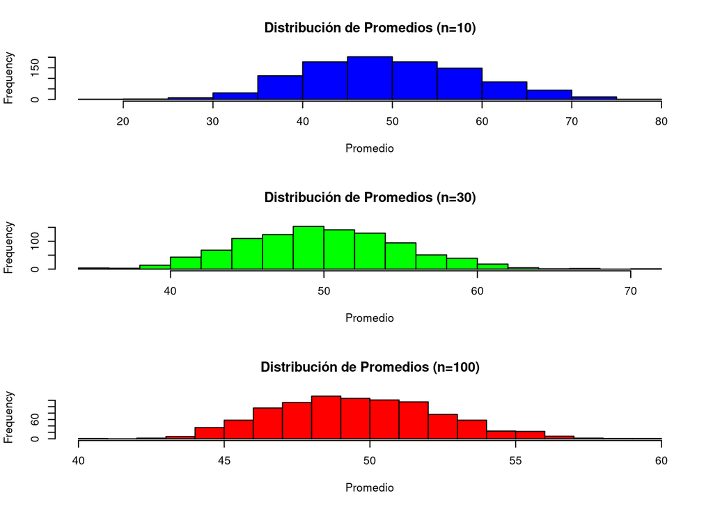

```r
# Ejemplo en R para visualizar el TLC
set.seed(123)

# Generar una población con distribución uniforme
population <- runif(10000, min = 0, max = 100)

# Función para calcular el promedio de una muestra
sample_means <- function(sample_size, n_samples) {
  means <- numeric(n_samples)
  for (i in 1:n_samples) {
    sample <- sample(population, size = sample_size, replace = TRUE)
    means[i] <- mean(sample)
  }
  return(means)
}

# Calcular promedios de muestras para diferentes tamaños de muestra
means_10 <- sample_means(10, 1000)
means_30 <- sample_means(30, 1000)
means_100 <- sample_means(100, 1000)

# Graficar los histogramas
par(mfrow = c(3, 1))
hist(means_10, main = "Distribución de Promedios (n=10)", xlab = "Promedio", col = "blue", breaks = 20)
hist(means_30, main = "Distribución de Promedios (n=30)", xlab = "Promedio", col = "green", breaks = 20)
hist(means_100, main = "Distribución de Promedios (n=100)", xlab = "Promedio", col = "red", breaks = 20)
```